# Lab book: CoV data summary

Liam Brierley (University of Liverpool)  
2020-04-06

## Numbers of viruses, sequences

*Search terms: (spike[Title] OR “S gene”[Title] OR “S protein”[Title] OR “S glycoprotein”[Title] OR “S1 gene”[Title] OR “S1 protein”[Title] OR “S1 glycoprotein”[Title] OR peplomer[Title] OR peplomeric[Title] OR peplomers[All Title] OR “complete genome”[Title]) NOT (patent[Title] OR vaccine OR artificial OR construct OR recombinant[Title])*

- **1585** viruses in family Coronaviridae identified through NCBI taxonomy.
- Of these **1585**, **573** (**36.2**%) have at least one available spike protein nucleotide sequence.
- Of these **573**, **53** (**9.2**%) have at least one recognised mammal or bird host in EID2 (which may be human host) *NB: virtually all coronaviruses are viruses of birds/mammals*
- Total sequence accessions: **16147**, made up of **40801** individual protein coding sequences

|  | host recognised | no hosts |
| --- | --- | --- |
| no spike sequence | 64 | 948 |
| spike sequence available | 53 | 520 |

**Number of sequences per coronavirus heavily skewed, most just have 1:**

| . | Freq |
| --- | --- |
| 1 | 457 |
| 2 | 49 |
| 3 | 7 |
| 4 | 5 |
| 5 | 1 |
| 6 | 5 |
| 7 | 1 |
| 8 | 2 |
| 10 | 2 |
| 11 | 2 |
| 12 | 2 |
| 13 | 2 |
| 14 | 1 |
| 15 | 1 |
| 16 | 2 |
| 17 | 2 |
| 19 | 2 |
| 23 | 1 |
| 26 | 2 |
| 27 | 1 |
| 31 | 2 |
| 32 | 1 |
| 33 | 1 |
| 35 | 1 |
| 43 | 1 |
| 51 | 1 |
| 54 | 1 |
| 60 | 1 |
| 66 | 1 |
| 71 | 1 |
| 75 | 1 |
| 86 | 1 |
| 150 | 1 |
| 151 | 1 |
| 172 | 1 |
| 173 | 1 |
| 361 | 1 |
| 393 | 1 |
| 590 | 1 |
| 660 | 1 |
| 739 | 1 |
| 753 | 1 |
| 991 | 1 |
| 3450 | 1 |
| 5915 | 1 |

|  | childtaxa_name | n_seqs |
| --- | --- | --- |
| 1581 | Human coronavirus OC43 | 739 |
| 1582 | Feline coronavirus | 753 |
| 1583 | Middle East respiratory syndrome-related coronavirus | 991 |
| 1584 | Porcine epidemic diarrhea virus | 3450 |
| 1585 | Infectious bronchitis virus | 5915 |

## SARS-CoV-2 sequences

- **151** spike protein nucleotide sequences identified by programmatic extraction from GenBank
- However, manual extraction from GenBank (download from [SARS-CoV-2 landing page](https://www.ncbi.nlm.nih.gov/genbank/sars-cov-2-seqs/) at 2020-03-27 18:15:04 GMT) find additional sequences not contained in these searches because metadata incorrectly labels them under taxid 694009 for SARS-CoV (the parent species).
- **95** sequences identified from manual extraction from GenBank (not as many as above, even with additional sequences, because again, not fully annotated, so can’t extract from searches)
- **2239** sequences identified from manual extraction from GISAID (all complete genomes, though proteins are not annotated..)

## Numbers of hosts

Considering only the 573 coronaviruses with available spike protein sequence data…

**Number of host species per coronavirus also heavily skewed, as expected:**

| . | Freq |
| --- | --- |
| 0 | 520 |
| 1 | 37 |
| 2 | 3 |
| 3 | 4 |
| 5 | 2 |
| 6 | 1 |
| 8 | 1 |
| 15 | 1 |
| 18 | 1 |
| 26 | 1 |
| 38 | 1 |
| 48 | 1 |

|  | childtaxa_name | Hostspp |
| --- | --- | --- |
| 569 | Severe acute respiratory syndrome-related coronavirus | 15 |
| 570 | Alphacoronavirus 1 | 18 |
| 571 | Betacoronavirus 1 | 26 |
| 572 | Bat coronavirus | 38 |
| 573 | Avian coronavirus | 48 |

*Coronaviruses with broadest host range include very wide species that encompass many individual strains..*

**Number of coronaviruses per host species also heavily skewed:**

| . | Freq |
| --- | --- |
| 0 | 1263 |
| 1 | 124 |
| 2 | 20 |
| 3 | 4 |
| 4 | 2 |
| 5 | 2 |
| 7 | 1 |
| 23 | 1 |

|  | . | Freq |
| --- | --- | --- |
| 1412 | mustela putorius | 4 |
| 1413 | rattus norvegicus | 4 |
| 1414 | sus scrofa | 5 |
| 1415 | vicugna pacos | 5 |
| 1416 | homo sapiens | 7 |
| 1417 | rhinolophus sinicus | 23 |

*As expected, some commonly studied species (ferret, rat, domestic pig, human), plus livestock (alpaca) and one horseshoe bat, sequences mostly derive from a [single study](https://www.nature.com/articles/nature12711)*

**Number of coronaviruses infecting each host group:**

Host groups are mutually exclusive, i.e. primates = non-human primates. Other mammals = misc orders (Proboscidea, Eulipotyphla, Cingulata..)

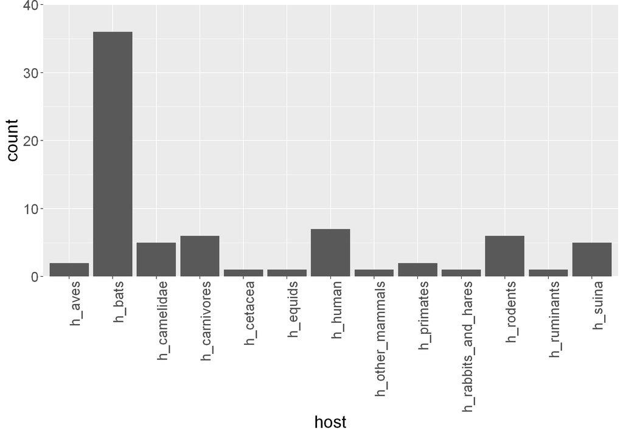

*Not too sure this is very meaningful given how little we know about potential animal hosts of coronaviruses*

## Sequence data quality

- Total sequence accessions: **16147**, most of which are only partial sequences for spike *(NB this distinction assigned using regexp searches in title, as most accessions are missing the “completeness” field and some appear incorrect)*

| Var1 | Freq |
| --- | --- |
| complete_spike | 0.1525361 |
| partial_spike | 0.6645197 |
| whole_genome | 0.1829442 |

- While most sequences are only partial, most coronaviruses with at least 1 sequence actually have at least 1 complete spike sequence (420 of 573).
- Trying to determine which protein coding sequences correspond to the spike proteins:
- 0.18% of coding sequences do not have a protein label annotation in metadata and 38.56% do not have a gene label annotation - using regular expressions based on proteins to determine whether each coding sequence is spike (may be entire S, or just S1 subunit, S2 subunit) or other:

|  | complete_spike | partial_spike | whole_genome |
| --- | --- | --- | --- |
| other | 1403 | 437 | 23099 |
| S | 2354 | 6798 | 2859 |
| S1 | 14 | 3722 | 0 |
| S2 | 10 | 41 | 0 |

**Excluding partial sequences**, summaries of counts of different complete spike protein sequence types *per coronavirus (taxid)*:

| 0 | 1 | 2 | 3 | 4 | 5 | 6 | 8 | 9 | 10 | 11 | 13 | 14 | 16 | 17 | 19 | 21 | 26 | 27 | 29 | 31 | 33 | 44 | 46 | 47 | 53 | 88 | 90 | 142 | 164 | … |
| --- | --- | --- | --- | --- | --- | --- | --- | --- | --- | --- | --- | --- | --- | --- | --- | --- | --- | --- | --- | --- | --- | --- | --- | --- | --- | --- | --- | --- | --- | --- |
| 8 | 315 | 47 | 7 | 5 | 3 | 5 | 2 | 1 | 2 | 1 | 3 | 2 | 1 | 2 | 1 | 1 | 2 | 1 | 1 | 1 | 2 | 2 | 1 | 2 | 1 | 1 | 1 | 1 | 1 | … |

So **5213** individual spike protein sequences across **420** viruses.

*NB further complete coding sequences are available that give subunits separately - for S1, 1 virus (Infectious bronchitis virus) and for S2, 1 virus (Porcine epidemic diarrhea virus). Not considering these for now.*

## Sequence data summaries

**Excluding partial sequences**, summaries of genomic characteristics *per coronavirus (taxid)* (i.e. values are averaged within each virus so that each virus represents only one data point):

*Only for viruses that have whole genome sequences, mean lengths:*

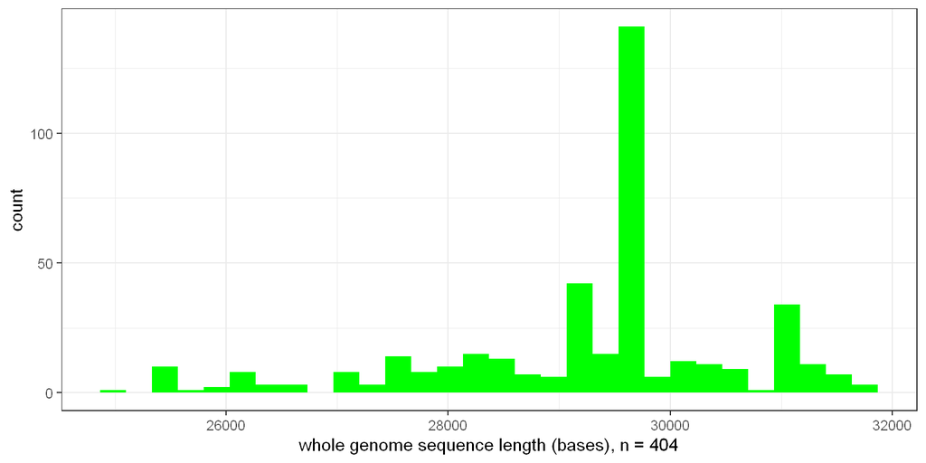

*Mean lengths, ENC, GC content of spike proteins compared to other proteins:*

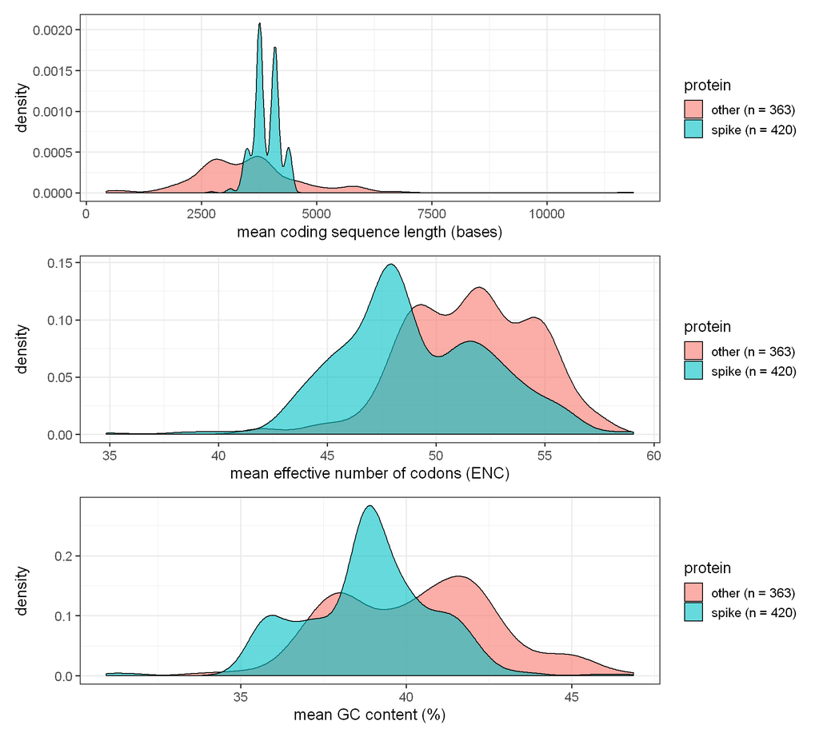

**Stronger codon bias in spike than other proteins. Reasonable variation between spike proteins, although GC content is more uniform than in other proteins!**